# Documentation for capsstone

Jad

12/6/2021

## Here We Go - Capstone Case Study: Cyclistic Bicycle Ride Sharing

```r
read.csv("Riders_2020_Q1_total_duration.csv")
```

```
##   X rider_type trips_total_mins trips_total_mins_in_1000s month
## 1 1     Member           522291                   522.291   Jan
## 2 2     Casual           192364                   192.364   Jan
## 3 3     Member           517992                   517.992   Feb
## 4 4     Casual           188065                   188.065   Feb
## 5 5     Member           521825                   521.825   Mar
## 6 6     Casual           191898                   191.898   Mar
```

```r
library(rmarkdown)
library(tidyverse)
library(ggplot2)
library(dplyr)
library(lubridate)
library(tidyr)
library(knitr)
```

### Questions:

1. How do annual members and casual riders use Cyclistic bikes differently?

### Consider key differences:

```r
trips_2020_Q1 <- read_csv("Divvy_Trips_2020_Q1.csv")
```

Rows: 426887 Columns: 13

```r
colnames(trips_2020_Q1)
```

```
##  [1] "ride_id"            "rideable_type"      "started_at"
##  [4] "ended_at"           "start_station_name" "start_station_id"
##  [7] "end_station_name"   "end_station_id"     "start_lat"
## [10] "start_lng"          "end_lat"            "end_lng"
## [13] "member_casual"
```

```r
 [1] "ride_id"            "rideable_type"      "started_at"         "ended_at"
 [5] "start_station_name" "start_station_id"   "end_station_name"   "end_station_id"
 [9] "start_lat"          "start_lng"          "end_lat"            "end_lng"
[13] "member_casual"
```

```r
count(trips_2020_Q1, member_casual)
```

casual 48480 member 378407

### rideable_type is all docked bikes

```r
trips_length <- select(trips_2020_Q1, started_at, ended_at, member_casual)
```

### Find trip duration for each trip:

```r
trips_length$trip_duration <- difftime( as.POSIXct( trips_length[[2]], format="%Y-%m-%dT%H:%M"), as.POSIXct( trips_length[[1]], format="%Y-%m-%dT%H:%M"), units="min")
```

### Reorder columns:

```r
trips_length <- trips_length[c(1, 2, 4, 3)]
```

```r
head(trips_length)
```

```r
           started_at            ended_at trip_duration member_casual
1 2020-01-21 20:06:59 2020-01-21 20:14:30 7.516667 mins        member
2 2020-01-30 14:22:39 2020-01-30 14:26:22 3.716667 mins        member
3 2020-01-09 19:29:26 2020-01-09 19:32:17 2.850000 mins        member
4 2020-01-06 16:17:07 2020-01-06 16:25:56 8.816667 mins        member
5 2020-01-30 08:37:16 2020-01-30 08:42:48 5.533333 mins        member
6 2020-01-10 12:33:05 2020-01-10 12:37:54 4.816667 mins        member
```

### Rename columns:

```r
colnames(trips_length) <- c("Started At", "Ended At", "Trip Duration", "Member Type")
```

### Calculate Max and Min durations

```r
max(trips_length$`Trip Duration`)
```

```r
Time difference of 156450.4 mins
```

```r
min(trips_length$`Trip Duration`)
```

Time difference of -9.2 mins

### How can that be a nagative number?

Maybe start and end time were recorded incorrectly. Also, many trips with 0 duration. Most of the longest trip durations were by casual riders.

group by and arrange descending by Trip Duration

```r
trips_by_duration <- trips_length %>% group_by(`Trip Duration`, `Member Type`) %>% arrange(desc(`Trip Duration`, desc(`Member Type`)))
```

```r
as_tibble(trips_by_duration)
```

### A tibble: 426,887 × 4

```r
   `Started At`        `Ended At`          `Trip Duration` `Member Type`
   <dttm>              <dttm>              <drtn>          <chr>
 1 2020-01-09 21:00:22 2020-04-27 12:30:46 156450.40 mins  casual
 2 2020-02-02 17:18:57 2020-05-12 16:15:42 143936.75 mins  casual
 3 2020-02-28 08:47:09 2020-05-19 20:10:34 117323.42 mins  casual
 4 2020-03-02 17:57:47 2020-05-06 21:11:18  93793.52 mins  member
 5 2020-01-26 10:24:05 2020-03-28 22:15:51  89991.77 mins  casual
 6 2020-02-09 10:23:26 2020-04-11 18:46:05  89782.65 mins  casual
 7 2020-02-08 19:04:12 2020-04-03 19:21:43  79217.52 mins  member
 8 2020-01-15 12:02:18 2020-03-07 09:05:39  74703.35 mins  casual
 9 2020-02-11 10:45:29 2020-03-30 17:10:20  69504.85 mins  casual
10 2020-02-01 04:24:36 2020-03-17 18:46:18  65661.70 mins  casual
```

### Convert Trip Duration as double

```r
trips_length$duration_as_int <- as.double(trips_length$`Trip Duration`)
```

### Having a hardddd time. Moving to Excel to work out some of the kinks in finding the average in trip duration.

```r
=AVG trip duration of all types of members = 22.1151047 mins
```

### From Excel, since it’s easier to do quick calculations

```r
Count Member    378,407
Count Casual    48,480
Total variables 426,887


If duration is > 15 mins    115,253
If duration is > 30 mins    32,478
If duration is < 10 mins  232,354

% of > 15 min rides 27.00%
% of > 30 min rides 7.61%
% of <10 min rides  54.43%
```

### Comparing 2020_Q1 data and 2019_Q1, I noticed that the data isn’t labeled the same. In 2019_Q1, they include different info about gender and label “members” and “customers” differently, as well as including birth year of the customer. Since this data isn’t included in all data sets, it isn’t very valuable. Also, 2019_Q1 has more data.

### make new column with months

```r
trips_length$month <- format(trips_length$`Started At`, format="%m")
```

###saved as a csv and will now visualize in Tableau

### Making data.frame from values and visualizing in R

```r
riders_2020_Q1 <- c('January Members', 'January Casual', 'February Members', 'February Casual', 'March Members', 'March Casual')
```

### getting values already input (numbers)

```r
trips_total_mins <- c(january_member_riders, january_casual_riders, february_member_riders, february_casual_riders, march_member_riders, march_casual_riders)
```

```r
rider_type <- riders_2020_Q1
```

```r
riders_2020_Q1_total_duration <- data.frame(rider_type, trips_total_mins)
```

### Make new column

```r
riders_2020_Q1_total_duration$trips_total_mins_in_1000s <- riders_2020_Q1_total_duration$trips_total_mins
```

### Make old column in reference to new column. Calculating minutees in hundreds of thousands

```r
riders_2020_Q1_total_duration$trips_total_mins <- riders_2020_Q1_total_duration$trips_total_mins*1000
```

### R VISUALIZATION

```r
bar_graph_of_2020_Q1_rider_times <- ggplot(riders_2020_Q1_total_duration, aes(rider_type, trips_total_mins_in_1000s)) + geom_bar(stat="identity", fill="steelblue") + geom_text(aes(label=trips_total_mins_in_1000s), vjust=1.6, color="white", size=3.5)
```

### Convert “January”, “February” etc. Strings into Dates

```r
riders_2020_Q1_total_duration$month <- c("2020-01-01", "2020-01-01", "2020-02-01", "2020-02-01", "2020-03-01", "2020-03-01") format(as.Date(riders_2020_Q1_total_duration$month), "%b")
```

```r
[1] "Jan" "Jan" "Feb" "Feb" "Mar" "Mar"
```

### Include into data frame

```r
riders_2020_Q1_total_duration$month <- format(as.Date(riders_2020_Q1_total_duration$month), "%b")
```

```r
riders_2020_Q1_total_duration$month = factor(riders_2020_Q1_total_duration$month, levels = month.abb)
```

### Then reintroduce into ggplot

### With Labels

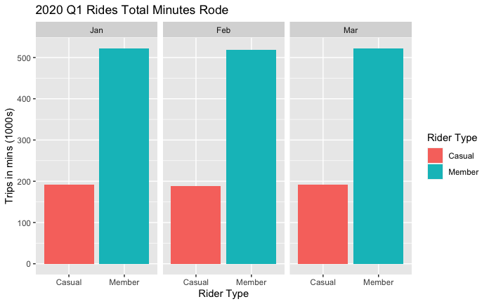

the final graph

```r
bar_graph_of_2020_Q1_rider_times <- ggplot(riders_2020_Q1_total_duration, aes(rider_type, trips_total_mins_in_1000s, fill = rider_type)) + geom_bar(stat="identity") + facet_wrap(~month) + labs(title="2020 Q1 Rides Total Minutes Rode", x = "Rider Type", y = "Trips in mins (1000s)", fill = "Rider Type")
```